# Analyzing the quality of red wines (by Aishwarya Venketeswaran)

#### correlation value determined by the pearson method is -0.057. Correlation

#### is low. pH is not a good predictor of quality.

## Graph of sulphates vs.quality

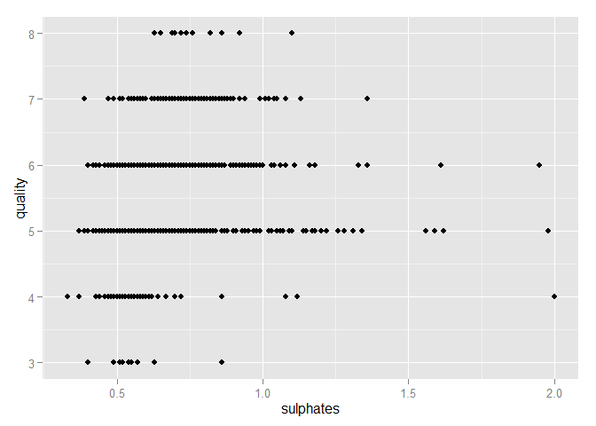

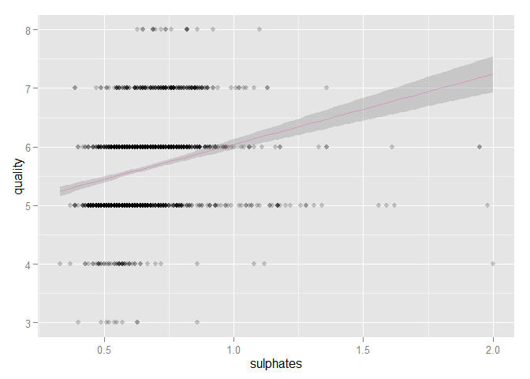

[figure not shown]

```
##
##  Pearson's product-moment correlation
##
## data:  pf$quality and pf$sulphates
## t = 10.38, df = 1597, p-value < 2.2e-16
## alternative hypothesis: true correlation is not equal to 0
## 95 percent confidence interval:
##  0.2049011 0.2967610
## sample estimates:
##       cor
## 0.2513971
```

#### The plots do not present a clear picture about a correlation. The

#### correlation value determined by the pearson method is 0.251. The correlation

#### value is not high; this probably is the reason why we cannot conclude much from

#### the graph. Hence, it does not make sense to use sulphate content as a predictor

#### for quality.

#### From the boxplot, we may guess that the relationahip is quadratic.

## Graph of alcohol content vs.quality

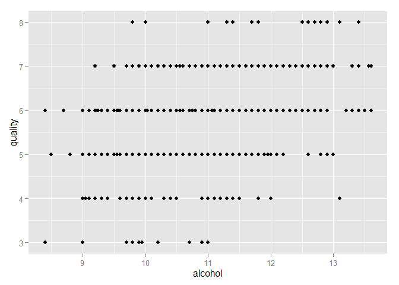

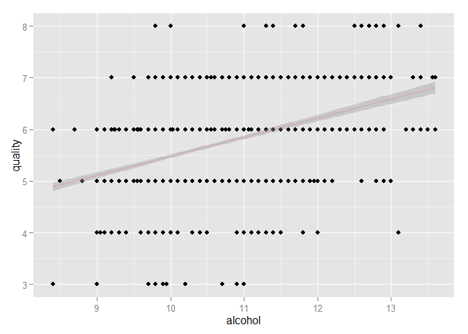

```
##
##  Pearson's product-moment correlation
##
## data:  pf$quality and pf$alcohol
## t = 21.639, df = 1597, p-value < 2.2e-16
## alternative hypothesis: true correlation is not equal to 0
## 95 percent confidence interval:
##  0.4373540 0.5132081
## sample estimates:
##       cor
## 0.4761663
```

#### The plots do not present a clear picture about a correlation. The

#### correlation value determined by the pearson method is 0.476. The correlation

#### value is not particularly high; this probably is the reason why we cannot

#### conclude much from the graph. Although this value is not high, this is the

#### highest correlation value found. Hence, we may consider the alcohol content

#### to be a good predictor.

## Graph of free sulfur dioxide vs. total sulfur dioxide

### Free sulfur dioxide is a subset of the total sulfur dioxide. Hence, it is

### expected that they’ll follow a linear relationship.

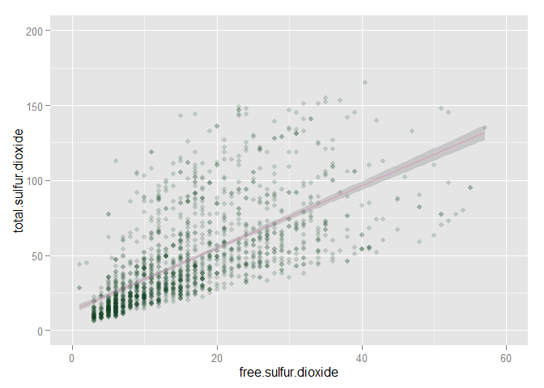

```
##
##  Pearson's product-moment correlation
##
## data:  pf$free.sulfur.dioxide and pf$total.sulfur.dioxide
## t = 35.84, df = 1597, p-value < 2.2e-16
## alternative hypothesis: true correlation is not equal to 0
## 95 percent confidence interval:
##  0.6395786 0.6939740
## sample estimates:
##       cor
## 0.6676665
```

#### As expected, the graph displays a linear relationship.

#### In order to eliminate some outliers from the

#### calculation, I set the x and y limits. Correlation is 0.667

#### This correlation value helps us conclude that there is a strong positive

#### linear relationship between free sulphur dioxide and total sulphur dioxide.

## Graph of acidity vs. pH

### Acidity and pH must have a high correlation and have an inversely proportional

### relationship.

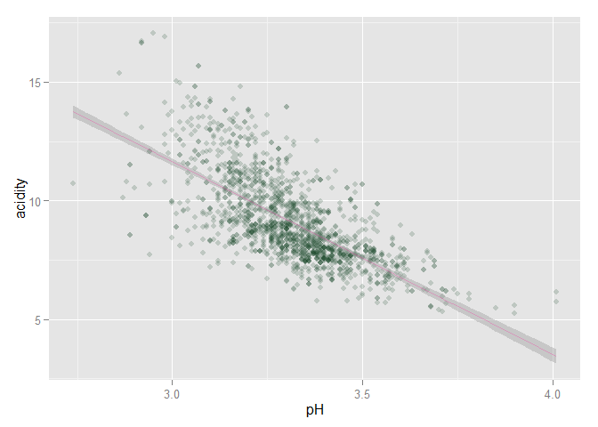

```
##
##  Pearson's product-moment correlation
##
## data:  pf$acidity and pf$pH
## t = -37.418, df = 1597, p-value < 2.2e-16
## alternative hypothesis: true correlation is not equal to 0
## 95 percent confidence interval:
##  -0.7087579 -0.6564574
## sample estimates:
##        cor
## -0.6834838
```

#### As expected, there is a high correlation between acidity and pH: -0.683.

#### Therefore, there is a negative strong linear relationship.

#### The relationship is inversely proportional. As the pH increases, the acidity

#### decreases. This makes sense because higher the pH, the more basic (less acidic)

#### a solution is.

## Graph of alcohol vs. quality and volatile acidity vs.quality

### Alcohol and quality, and Volatile acidity and quality have high correlation

### values. How do they compare?

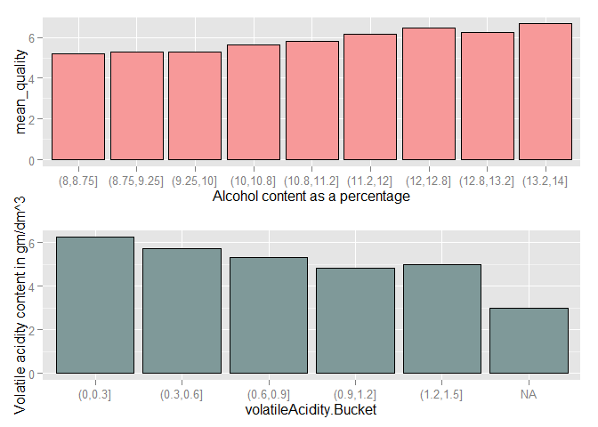

#### New variables I defined in this section are:

#### alcoholBucket: Defines buckets for alcohol in order to better visualize

#### patterns.

#### volatileAcidity.Bucket: Defines buckets for volatile acidity in order to

#### better visualize patterns.

#### wines: Defines a datset containing the various alcohol buckets and their

#### mean quality in order to better visualize patterns.

#### winesVol: Defines a datset containing the various volatile acidity buckets and their

#### mean quality in order to better visualize patterns.

#### In these above graphs, it can be seen clearly the overall trends: as alcohol

#### content increases, the quality (mean) increases and that as the volatile

#### acidity increases, the quality (mean) decreases. I have set up buckets for

#### alcohol content and volatile acidity content to visualize well. Also, the

#### outliers of the alcohol content values have been removed.

# Bivariate Analysis

### Talk about some of the relationships you observed in this part of the

### investigation. How did the feature(s) of interest vary with other features

### in the dataset?

#### correlation was the strongest in this set - 0.48.

### Did you observe any interesting relationships between the other features

### (not the main feature(s) of interest)?

#### - As expected, there is a high correlation between acidity and pH: -0.683 ;

#### the relationship is inversely proportional. Hence, as the acidity increases,

#### the pH decreases.

#### - Since free sulfur dioxide is a subset of the total sulfur dioxide, the

#### graph portrayed a linear relationship. The correlation is reasonably high -

#### 0.667.

### What was the strongest relationship you found?

#### From the plots made, it can be concluded that the following variables have the

#### highest correlation with wine quality: taste(0.24), volatile acidity(0.39),

#### citric acid(0.22), sulfates(0.25) and alcohol content(0.48).

#### The strongest relationship was between quality and alcohol content (0.48).

# Multivariate Plots Section

## Graph of sulphate content and alcohol content vs. quality

### How are sulphates content and alcohol content influencing the quality?

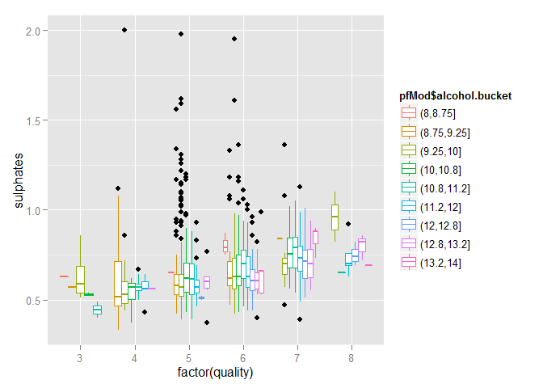

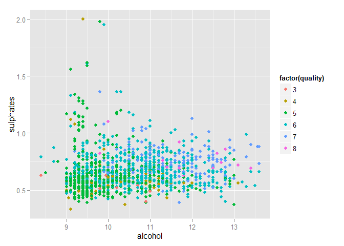

#### From this graph, it is difficult to make any inferences.

#### Another graph that represents the info better -

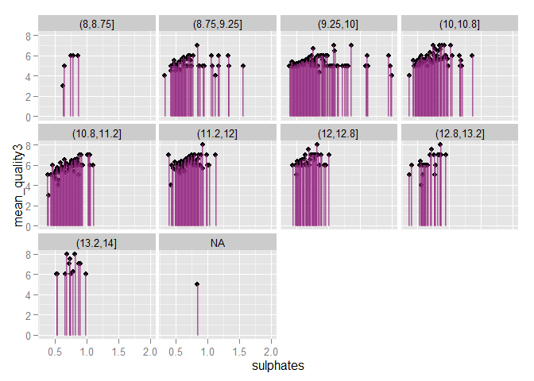

## Graph of taste and alcohol content vs. quality

### How are taste and alcohol influencing the quality?

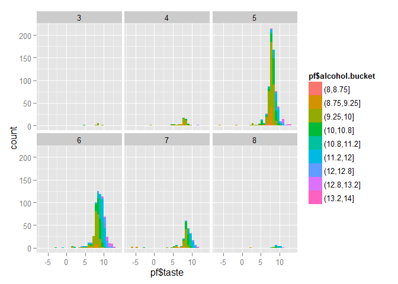

#### Let me try making another graph that provides the same info in a better

#### format. This is a different plot that provides more info-

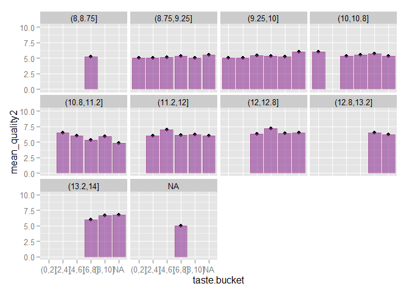

#### New variables defined in this section are:

#### taste.bucket represents the buckets of taste to categorize taste levels.

#### winesTastesQuality contains info about the mean quality level for a given

#### taste and alcohol level.

#### Wines with alcohol level between 12-12.8 and taste level between 6-8 have

#### the best quality [7.5].

#### It looks like wines with alcohol level between 9.25-10 are very common.

#### Also, wines with alcohol level greater than 10.8 tend to have high quality

#### irrespective of the taste level.

## Graph of citric acid and alcohol content vs. quality

### How are citric acids and alcohol influencing the quality?

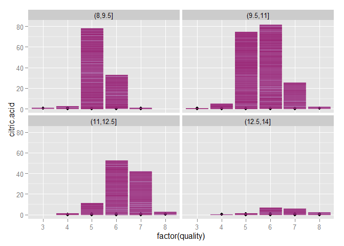

#### In the above graph, I have used jitter and size variables to ensure the

#### can clearly present info. Additionally, the alcohol buckets have been

#### changed.

#### New variable alcohol.bucket2 represents a differnt set of alcohol buckets

#### to present info better.

#### From the graph, wines with higher citric acid and higher alcohol content,

#### tend to have better quality.

#### Overall, wines with higher alcohol content have higher quality.

#### Within a particular alcohol content, wines with more citric acid tend to

#### have higher quality [except in wines with alcohol content between 8-9.5]

#### Wines with alchol content between 8-9.5, irrespective of citric acid

#### levels, have the same quality - 5.

## Graph of citric acid and volatile acidity vs. quality

### How are citric acid and volatile acidity influencing the quality?

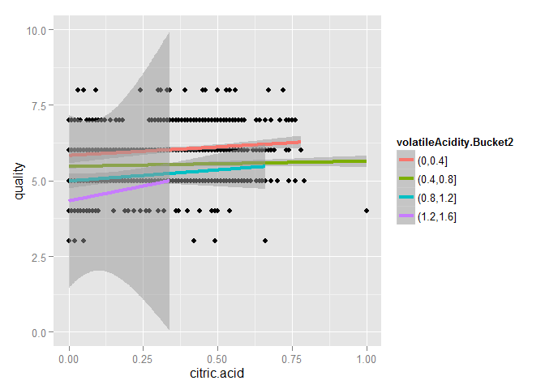

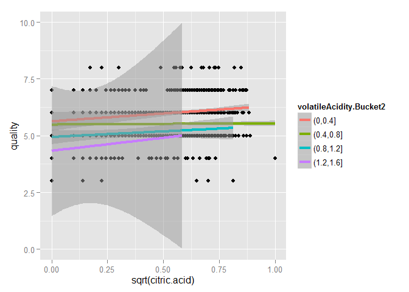

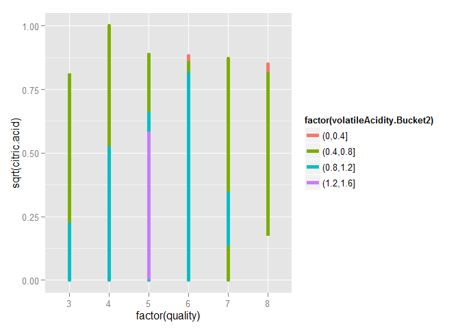

#### From this graph, we can conclude that wines with lower volatile acidity

#### levels tend to have higher quality. Because the first graph did not clearly

#### convey information about the relationships, I tried applying a

#### transformation in the second graph [sqrt].

#### New variable volatileAcidity.bucket2 represents a different set of buckets

#### to present info better.

#### From the square root of citric acid vs. quality (for various volatile acidity

#### content), it is clear that lower volatile acid content tends to have higher

#### quality (irrespective of sqrt(citric acid).

#### Wines with same volatile acidity levels have the same quality irrespective

#### of citric acid levels.

## Graph of volatile acidity and alcohol vs. quality

### How are volatile acidity and alcohol influencing the quality?

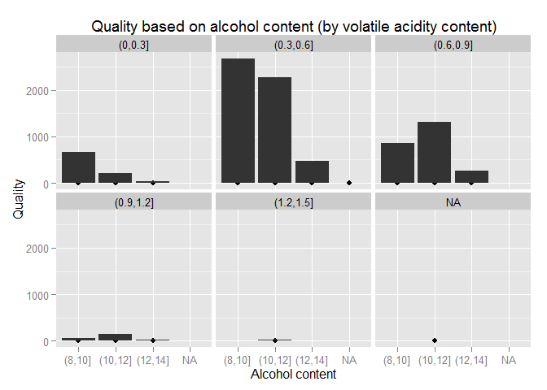

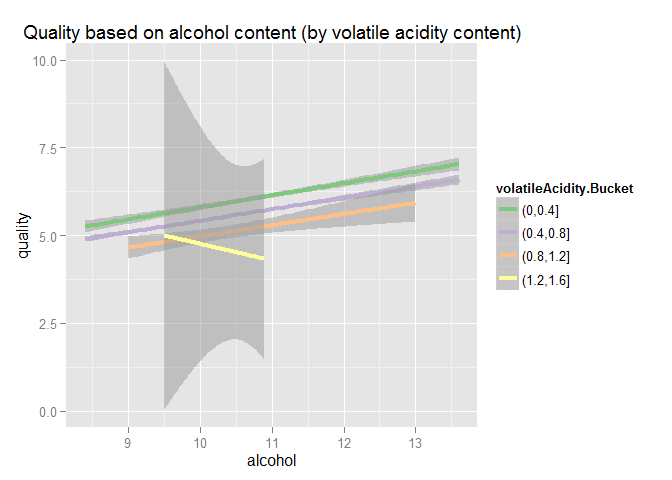

```
##
##  Pearson's product-moment correlation
##
## data:  (1/pfMod$alcohol) * sqrt(pfMod$volatile.acidity) and pfMod$quality
## t = -24.561, df = 1589, p-value < 2.2e-16
## alternative hypothesis: true correlation is not equal to 0
## 95 percent confidence interval:
##  -0.5592898 -0.4879996
## sample estimates:
##        cor
## -0.5245636
```

#### Also, we can conclude that lower volatile acidity have higher quality.

#### From the second graph, it can be concluded that lower volatile acidity

#### content leads to higher quality.The slope of the lines is very low; hence,

#### we cannot conclude that higher alcohol content and low volatile acidity

#### leads to better quality.

#### The graph also shows that volatile acidity level between 0-0.4 lead to

# Multivariate Analysis

### OPTIONAL: Did you create any models with your dataset? Discuss the strength

### and limitations of your model.

#### No, I did not create any models.

# Final Plots and Summary

## Plot One

## Total acidity values of all wines vs. the number of wines.

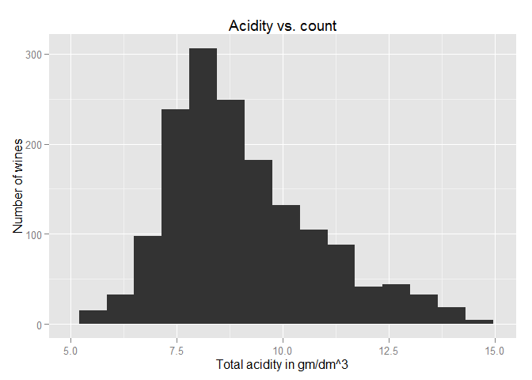

### Description One

#### 7.82 and 10.07.

## Plot Two

## Alcohol content vs. mean quality and volatile acidity vs. mean quality

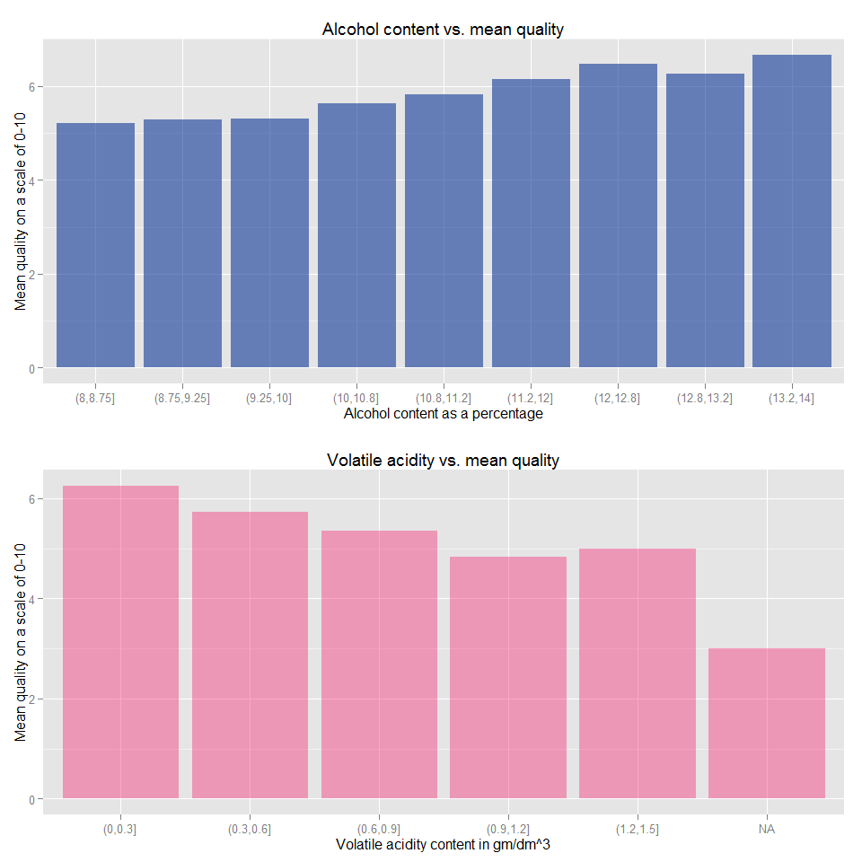

### Description Two

#### In these above graphs, it can be seen clearly the overall

#### trends: as alcohol content increases, the quality (mean) increases and that as

#### the volatile acidity increases, the quality (mean) decreases. I have set up

#### buckets for alcohol content and volatile acidity content to visualize well.

#### Also, the outliers of the alcohol content values have been removed.

#### In this case, quality is not a discrete value because it is the average quality.

## Plot Three

## Quality based on alcohol content (by volatile acidity content)

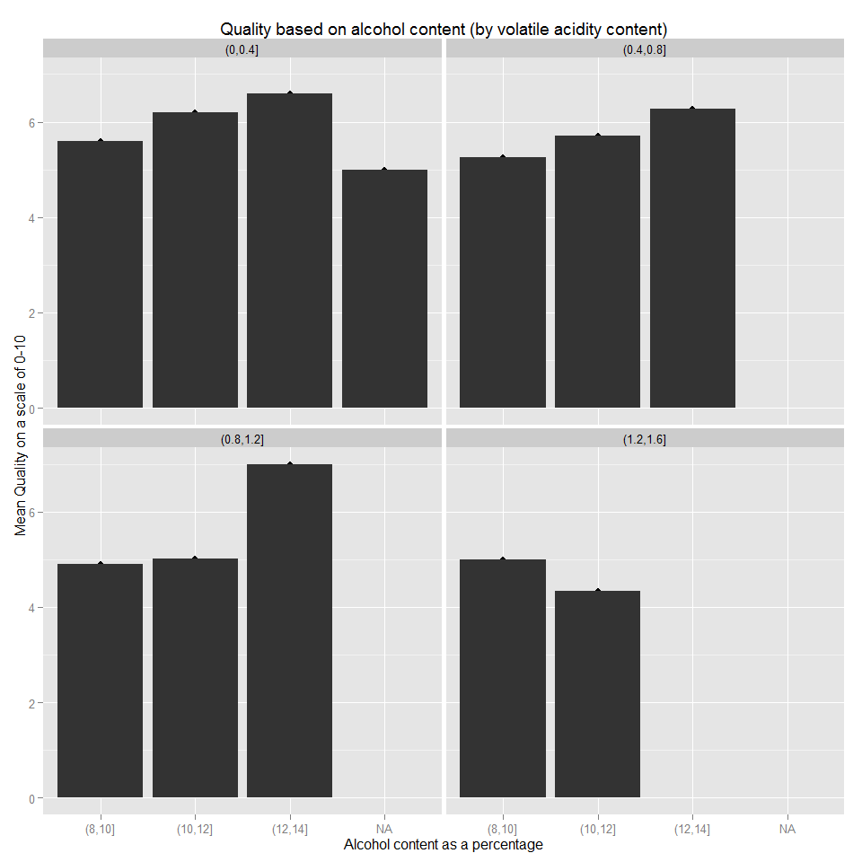

### Description Three

#### In this case, quality is not a discrete value because it is the average quality.

#### New variables I defined in this section are:

#### alcoholBucket: Redefined buckets for alcohol in order to better visualize

#### patterns.

#### volatileAcidity.Bucket: Redefined buckets for volatile acidity in order to

#### better visualize patterns.

#### winesGrouping: Defines a datset containing the various alcohol buckets,

#### volatile acidity buckets and their mean quality in order to better visualize patterns.

# Reflection

#### I faced several difficulties in this project. Firstly, since the variables

#### provided in the dataset already (like fixed acidity, volatile acidity,etc.)

#### are not factors that are easily percivable by the human mind, it took me

#### some time to understand and recognize relationships. Also, once the

#### relationships were found, they did not seem intuitive. I also had to create

#### new variables that are easier to understand and interpret such as taste and

#### acidity. Secondly, the form of the data (all variables of type int/num)

#### made it difficult to develop plots and determine relationships. In order to

#### resolve this problem, I create buckets for alcohol and volatile acidity. I

#### am very happy to have done the analysis and discovered several

#### relationships among variables and find predictors for quality. I recognize

#### that the analysis that I have done is 100% complete. In the future, I would

#### like to develop a predictor model for predicting the quality of wine. I

#### think I am close to the model at this point by having determined the

#### relationships among variables. Another point to note is that most of the

#### analysis has been based on the pearson correlation values. However, this

#### correlation value represents the existence and strength of a linear

#### relationship between the variables.Hence, a 0 correlation value does not

#### imply that the variables are independent - it only implies the lack of a

#### linear relationship. Hence, in this case, I might have not discovered

#### some non-linear relationships.